# Group Summaries and Statistics

Christina Maimone

This isn’t a statistics workshop; we’re going to focus on the code here, not when to use different methods or how to interpret the results. You’ll likely need to do more learning later about the specific models you use in your research. If there’s a method here you’re unfamiliar with (linear regression, ANOVA), that’s OK. Just covering some of the basics that many different fields use.

# Setup

The file uses the ggplot2 library to make a plot to show something about the data. You don’t need to know ggplot2 for this workshop. Install the ggplot2 package first if you don’t have it already.

```r
library(ggplot2)
```

# Data

## Penguins

We’re going to use data on penguins from the palmerpenguins package. Install the package first if you don’t have it already.

If you have it installed, just load it:

```r
library(palmerpenguins)
```

Here’s what’s in the data:

```r
penguins
```

| species | island | bill_length_mm | bill_depth_mm | flipper_length_mm | body_mass_g | sex | year |
| --- | --- | --- | --- | --- | --- | --- | --- |
| Adelie | Torgersen | 39.1 | 18.7 | 181 | 3750 | male | 2007 |
| Adelie | Torgersen | 39.5 | 17.4 | 186 | 3800 | female | 2007 |
| Adelie | Torgersen | 40.3 | 18.0 | 195 | 3250 | female | 2007 |
| Adelie | Torgersen | NA | NA | NA | NA | NA | 2007 |
| Adelie | Torgersen | 36.7 | 19.3 | 193 | 3450 | female | 2007 |
| Adelie | Torgersen | 39.3 | 20.6 | 190 | 3650 | male | 2007 |
| Adelie | Torgersen | 38.9 | 17.8 | 181 | 3625 | female | 2007 |
| Adelie | Torgersen | 39.2 | 19.6 | 195 | 4675 | male | 2007 |
| Adelie | Torgersen | 34.1 | 18.1 | 193 | 3475 | NA | 2007 |
| Adelie | Torgersen | 42.0 | 20.2 | 190 | 4250 | NA | 2007 |

[output cut: 334 more lines]

## Housing Data

For a second data set, we’re going to use some data on houses and their sales prices. Install the AmesHousing package.

```r
install.packages("AmesHousing")
```

```r
library(AmesHousing)
names(ames_raw)
```

```
##  [1] "Order"           "PID"             "MS SubClass"     "MS Zoning"
##  [5] "Lot Frontage"    "Lot Area"        "Street"          "Alley"
##  [9] "Lot Shape"       "Land Contour"    "Utilities"       "Lot Config"
## [13] "Land Slope"      "Neighborhood"    "Condition 1"     "Condition 2"
## [17] "Bldg Type"       "House Style"     "Overall Qual"    "Overall Cond"
## [21] "Year Built"      "Year Remod/Add"  "Roof Style"      "Roof Matl"
## [25] "Exterior 1st"    "Exterior 2nd"    "Mas Vnr Type"    "Mas Vnr Area"
## [29] "Exter Qual"      "Exter Cond"      "Foundation"      "Bsmt Qual"
## [33] "Bsmt Cond"       "Bsmt Exposure"   "BsmtFin Type 1"  "BsmtFin SF 1"
## [37] "BsmtFin Type 2"  "BsmtFin SF 2"    "Bsmt Unf SF"     "Total Bsmt SF"
## [41] "Heating"         "Heating QC"      "Central Air"     "Electrical"
## [45] "1st Flr SF"      "2nd Flr SF"      "Low Qual Fin SF" "Gr Liv Area"
## [49] "Bsmt Full Bath"  "Bsmt Half Bath"  "Full Bath"       "Half Bath"
## [53] "Bedroom AbvGr"   "Kitchen AbvGr"   "Kitchen Qual"    "TotRms AbvGrd"
## [57] "Functional"      "Fireplaces"      "Fireplace Qu"    "Garage Type"
## [61] "Garage Yr Blt"   "Garage Finish"   "Garage Cars"     "Garage Area"
## [65] "Garage Qual"     "Garage Cond"     "Paved Drive"     "Wood Deck SF"
## [69] "Open Porch SF"   "Enclosed Porch"  "3Ssn Porch"      "Screen Porch"
## [73] "Pool Area"       "Pool QC"         "Fence"           "Misc Feature"
## [77] "Misc Val"        "Mo Sold"         "Yr Sold"         "Sale Type"
## [81] "Sale Condition"  "SalePrice"
```

These variable names aren’t easy to type because of spaces and special characters. We wouldn’t be able to use them easily with the `$` syntax. I’m going to clean them up with the janitor package, which you may need to install if you haven’t before:

```r
install.packages("janitor")
```

I only need to use one function. Instead of loading the package, I’m going to prefix the function name with the package name:

```r
ames <- janitor::clean_names(ames_raw)
names(ames)
```

```
##  [1] "order"           "pid"             "ms_sub_class"    "ms_zoning"
##  [5] "lot_frontage"    "lot_area"        "street"          "alley"
##  [9] "lot_shape"       "land_contour"    "utilities"       "lot_config"
## [13] "land_slope"      "neighborhood"    "condition_1"     "condition_2"
## [17] "bldg_type"       "house_style"     "overall_qual"    "overall_cond"
## [21] "year_built"      "year_remod_add"  "roof_style"      "roof_matl"
## [25] "exterior_1st"    "exterior_2nd"    "mas_vnr_type"    "mas_vnr_area"
## [29] "exter_qual"      "exter_cond"      "foundation"      "bsmt_qual"
## [33] "bsmt_cond"       "bsmt_exposure"   "bsmt_fin_type_1" "bsmt_fin_sf_1"
## [37] "bsmt_fin_type_2" "bsmt_fin_sf_2"   "bsmt_unf_sf"     "total_bsmt_sf"
## [41] "heating"         "heating_qc"      "central_air"     "electrical"
## [45] "x1st_flr_sf"     "x2nd_flr_sf"     "low_qual_fin_sf" "gr_liv_area"
## [49] "bsmt_full_bath"  "bsmt_half_bath"  "full_bath"       "half_bath"
## [53] "bedroom_abv_gr"  "kitchen_abv_gr"  "kitchen_qual"    "tot_rms_abv_grd"
## [57] "functional"      "fireplaces"      "fireplace_qu"    "garage_type"
## [61] "garage_yr_blt"   "garage_finish"   "garage_cars"     "garage_area"
## [65] "garage_qual"     "garage_cond"     "paved_drive"     "wood_deck_sf"
## [69] "open_porch_sf"   "enclosed_porch"  "x3ssn_porch"     "screen_porch"
## [73] "pool_area"       "pool_qc"         "fence"           "misc_feature"
## [77] "misc_val"        "mo_sold"         "yr_sold"         "sale_type"
## [81] "sale_condition"  "sale_price"
```

These names are a bit harder to read, but they easier to type in R.

Let’s order the names

```r
sort(names(ames))
```

```
##  [1] "alley"           "bedroom_abv_gr"  "bldg_type"       "bsmt_cond"
##  [5] "bsmt_exposure"   "bsmt_fin_sf_1"   "bsmt_fin_sf_2"   "bsmt_fin_type_1"
##  [9] "bsmt_fin_type_2" "bsmt_full_bath"  "bsmt_half_bath"  "bsmt_qual"
## [13] "bsmt_unf_sf"     "central_air"     "condition_1"     "condition_2"
## [17] "electrical"      "enclosed_porch"  "exter_cond"      "exter_qual"
## [21] "exterior_1st"    "exterior_2nd"    "fence"           "fireplace_qu"
## [25] "fireplaces"      "foundation"      "full_bath"       "functional"
## [29] "garage_area"     "garage_cars"     "garage_cond"     "garage_finish"
## [33] "garage_qual"     "garage_type"     "garage_yr_blt"   "gr_liv_area"
## [37] "half_bath"       "heating"         "heating_qc"      "house_style"
## [41] "kitchen_abv_gr"  "kitchen_qual"    "land_contour"    "land_slope"
## [45] "lot_area"        "lot_config"      "lot_frontage"    "lot_shape"
## [49] "low_qual_fin_sf" "mas_vnr_area"    "mas_vnr_type"    "misc_feature"
## [53] "misc_val"        "mo_sold"         "ms_sub_class"    "ms_zoning"
## [57] "neighborhood"    "open_porch_sf"   "order"           "overall_cond"
## [61] "overall_qual"    "paved_drive"     "pid"             "pool_area"
## [65] "pool_qc"         "roof_matl"       "roof_style"      "sale_condition"
## [69] "sale_price"      "sale_type"       "screen_porch"    "street"
## [73] "tot_rms_abv_grd" "total_bsmt_sf"   "utilities"       "wood_deck_sf"
## [77] "x1st_flr_sf"     "x2nd_flr_sf"     "x3ssn_porch"     "year_built"
## [81] "year_remod_add"  "yr_sold"
```

Now, make two variables that I want to use later:

Combine square footage measures into a new variable

```r
ames$sf <- ames$total_bsmt_sf + ames$x1st_flr_sf + ames$x2nd_flr_sf
```

And make an indicator variable for single family homes:

```r
ames$single_family <- ames$bldg_type == "1Fam"
```

# Summarize by Group

We learned how to subset our data frame, so if we want to compute a measure by group in our data, we could do it on subsets. But there are functions in R that will help us aggregate our data by categorical variables and compute summary measures.

First, `tapply`, which applies a function to a vector grouped by a second vector.

```r
tapply(vector to compute on,
       vector with groups,
       name of the function,
       optionally any arguments to the function besides the data vector)
```

```r
tapply(penguins$bill_length_mm,   # vector to compute on
       penguins$species,  # vector with groups
       mean,  # name of the function
       na.rm = TRUE)  # optionally any arguments to the function besides the data vector
```

```
##    Adelie Chinstrap    Gentoo
##  38.79139  48.83382  47.50488
```

We can group by two different grouping variables by combining them in a list. Lists can hold objects of different types or the same type. For now, since we haven’t covered lists, just know that this is the syntax to group by two different groups.

```r
tapply(penguins$bill_length_mm,   # vector to compute on
       list(penguins$species, penguins$island),  # vector with groups
       mean,  # name of the function
       na.rm = TRUE)  # optionally any arguments to the function besides the data vector
```

```
##             Biscoe    Dream Torgersen
## Adelie    38.97500 38.50179  38.95098
## Chinstrap       NA 48.83382        NA
## Gentoo    47.50488       NA        NA
```

Why are there still `NA` in the output if we removed missing values when computing the mean? Because there are no observations with those combinations of variables in the data – no [Gentoo penguins](https://en.wikipedia.org/wiki/Gentoo_penguin) on [Dream island](https://en.wikipedia.org/wiki/Dream_Island) in our data.

`aggregate()` is similar to `tapply` but produces output in a different format

```r
aggregate(penguins$bill_length_mm,  # data to compute on
          list(penguins$species, penguins$island),  # groups: it expects a list here
          mean,  # function
          na.rm=TRUE)   # additional arguments to the function
```

| Group.1 | Group.2 | x |
| --- | --- | --- |
| Adelie | Biscoe | 38.97500 |
| Gentoo | Biscoe | 47.50488 |
| Adelie | Dream | 38.50179 |
| Chinstrap | Dream | 48.83382 |
| Adelie | Torgersen | 38.95098 |

We could also use the formula syntax, which we’ll learn more about shortly. This approach gives us better names in the resulting data frame. It wants `variable ~ group1` or `variable ~ group1 + group2`, with `data` specified. Because we tell it what data frame to use (`data = pengiuns`), we can reference the column names alone. The formula syntax then knows where to find those columns.

```r
aggregate(bill_length_mm ~ species + island,
          data = penguins,
          mean,
          na.rm=TRUE)
```

| species | island | bill_length_mm |
| --- | --- | --- |
| Adelie | Biscoe | 38.97500 |
| Gentoo | Biscoe | 47.50488 |
| Adelie | Dream | 38.50179 |
| Chinstrap | Dream | 48.83382 |
| Adelie | Torgersen | 38.95098 |

## EXERCISE

Compute group means of `body_mass_g` by `sex` with `tapply()` and `aggregate()`.

Use `tapply()`

Use `aggregate()`

# Correlation

```r
cor(penguins$bill_depth_mm, penguins$bill_length_mm)
```

```
## [1] NA
```

Those missing values again!

```r
cor(penguins$bill_depth_mm, penguins$bill_length_mm,
    use = "pairwise")
```

```
## [1] -0.2350529
```

There are different methods. Default (above) is pearson – “normal” correlation for continuous variables.

There are also rank (non-parametric) correlations:

```r
cor(penguins$bill_depth_mm, penguins$bill_length_mm,
    use = "pairwise",
    method = "kendall")
```

```
## [1] -0.1228502
```

```r
cor(penguins$bill_depth_mm, penguins$bill_length_mm,
    use = "pairwise",
    method = "spearman")
```

```
## [1] -0.2217492
```

Is our correlation “significant”?

```r
cor.test(penguins$bill_depth_mm, penguins$bill_length_mm,
    use = "pairwise")
```

```
##
##  Pearson's product-moment correlation
##
## data:  penguins$bill_depth_mm and penguins$bill_length_mm
## t = -4.4591, df = 340, p-value = 1.12e-05
## alternative hypothesis: true correlation is not equal to 0
## 95 percent confidence interval:
##  -0.3328072 -0.1323004
## sample estimates:
##        cor
## -0.2350529
```

This seems strange that there’s a negative correlation between these measures. Let’s look at the data (black line is the overall relationship, colored lines are for each species):

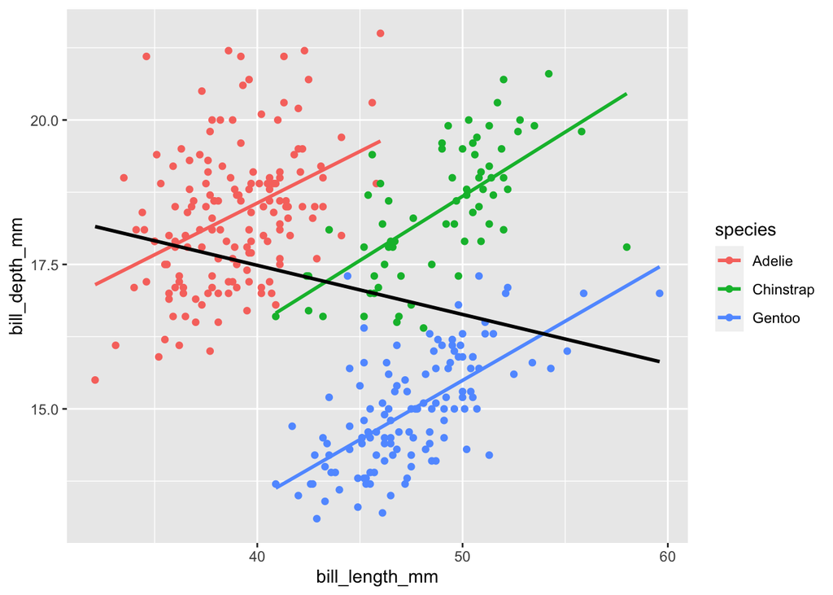

```r
ggplot(penguins, aes(x=bill_length_mm,
                     y=bill_depth_mm,
                     color=species)) +
  geom_point() +
  geom_smooth(method="lm", se=FALSE) +
  geom_smooth(method="lm", se=FALSE, color="black", mapping=aes(group=1))
```

What’s going on? Simpson’s Paradox. The relationship in the groups is different within groups vs. overall.

We need to compute the correlation separately for each group. Unfortunately, `tapply()` and `aggregate()` don’t work, because `cor()` expects two vectors to compute a single correlation.

There are multiple ways we could do this, including a [function](https://personality-project.org/r/html/statsBy.html) in the `psych` package (written by Northwestern’s own Bill Revelle) that will let you compute correlation and other statistics by group.

Or we could do it manually here for practice subsetting data!

## EXERCISE

Compute the correlation between `bill_length_mm` and `bill_depth_mm` for each of the three species (“Adelie”, “Chinstrap”, “Gentoo”) separately (remember to run code above to load libraries and data):

```r
cor(___, ___, use = "pairwise")
cor(___, ___, use = "pairwise")
cor(___, ___, use = "pairwise")
```

We can also use `cor()` to compute a correlation matrix between multiple variables at once by supplying a data frame with just numeric columns or matrix instead of two vectors.

```r
# Which are the numeric variables?
head(penguins)
```

| species | island | bill_length_mm | bill_depth_mm | flipper_length_mm | body_mass_g | sex | year |
| --- | --- | --- | --- | --- | --- | --- | --- |
| Adelie | Torgersen | 39.1 | 18.7 | 181 | 3750 | male | 2007 |
| Adelie | Torgersen | 39.5 | 17.4 | 186 | 3800 | female | 2007 |
| Adelie | Torgersen | 40.3 | 18.0 | 195 | 3250 | female | 2007 |
| Adelie | Torgersen | NA | NA | NA | NA | NA | 2007 |
| Adelie | Torgersen | 36.7 | 19.3 | 193 | 3450 | female | 2007 |
| Adelie | Torgersen | 39.3 | 20.6 | 190 | 3650 | male | 2007 |

```r
penguins[,3:6]
```

| bill_length_mm | bill_depth_mm | flipper_length_mm | body_mass_g |
| --- | --- | --- | --- |
| 39.1 | 18.7 | 181 | 3750 |
| 39.5 | 17.4 | 186 | 3800 |
| 40.3 | 18.0 | 195 | 3250 |
| NA | NA | NA | NA |
| 36.7 | 19.3 | 193 | 3450 |
| 39.3 | 20.6 | 190 | 3650 |
| 38.9 | 17.8 | 181 | 3625 |
| 39.2 | 19.6 | 195 | 4675 |
| 34.1 | 18.1 | 193 | 3475 |
| 42.0 | 20.2 | 190 | 4250 |

[output cut: 334 more lines]

Correlation of just the numeric columns

```r
cor(penguins[, 3:6],
    use = "pairwise")
```

```
##                   bill_length_mm bill_depth_mm flipper_length_mm body_mass_g
## bill_length_mm         1.0000000    -0.2350529         0.6561813   0.5951098
## bill_depth_mm         -0.2350529     1.0000000        -0.5838512  -0.4719156
## flipper_length_mm      0.6561813    -0.5838512         1.0000000   0.8712018
## body_mass_g            0.5951098    -0.4719156         0.8712018   1.0000000
```

Correlation just for a subgroup – choosing a subset of rows

```r
cor(penguins[penguins$species=="Chinstrap", 3:6],
    use = "pairwise")
```

```
##                   bill_length_mm bill_depth_mm flipper_length_mm body_mass_g
## bill_length_mm         1.0000000     0.6535362         0.4716073   0.5136383
## bill_depth_mm          0.6535362     1.0000000         0.5801429   0.6044983
## flipper_length_mm      0.4716073     0.5801429         1.0000000   0.6415594
## body_mass_g            0.5136383     0.6044983         0.6415594   1.0000000
```

# T-Test

A t-test lets us determine if the mean of variable is different from some value, or if the means of two groups are statistically different from each other.

If we have a variable that splits our data into two groups, we can use the formula syntax here `variable ~ groups`:

```r
t.test(body_mass_g ~ sex, data=penguins)
```

```
##
##  Welch Two Sample t-test
##
## data:  body_mass_g by sex
## t = -8.5545, df = 323.9, p-value = 4.794e-16
## alternative hypothesis: true difference in means between group female and group male is not equal to 0
## 95 percent confidence interval:
##  -840.5783 -526.2453
## sample estimates:
## mean in group female   mean in group male
##             3862.273             4545.685
```

It drops rows/observations with missing values.

Or we can supply two separate vectors of values to compare:

```r
# same as above
t.test(penguins$body_mass_g[penguins$sex == "male"],
       penguins$body_mass_g[penguins$sex == "female"])
```

```
##
##  Welch Two Sample t-test
##
## data:  penguins$body_mass_g[penguins$sex == "male"] and penguins$body_mass_g[penguins$sex == "female"]
## t = 8.5545, df = 323.9, p-value = 4.794e-16
## alternative hypothesis: true difference in means is not equal to 0
## 95 percent confidence interval:
##  526.2453 840.5783
## sample estimates:
## mean of x mean of y
##  4545.685  3862.273
```

## EXERCISE

Using the `ames` data, do `single_family` homes have greater `sf` (square footage) than other types of homes?

Hint: `single_family` is a variable we created above that has TRUE/FALSE values (so two groups).

# Chi-squared

If we have two categorical variables (instead of one continuous and one categorical), we can use a chi-squared test to see if there’s an association between the variables:

```r
ames$stories <- ifelse(ames$house_style %in% c("1.5Fin", "1.5Unf", "1Story"), "1 story", "2 story")
table(ames$stories, ames$garage_finish)
```

```
##
##           Fin RFn Unf
##   1 story 374 478 854
##   2 story 354 334 377
```

```r
chisq.test(ames$stories, ames$garage_finish)
```

```
##
##  Pearson's Chi-squared test
##
## data:  ames$stories and ames$garage_finish
## X-squared = 66.182, df = 2, p-value = 4.255e-15
```

# ANOVA

ANOVA extends the idea of a t-test to more groups. We can see if the average values of a continuous variable are different for different groups. We use `aov()` to run the model.

```r
aov(body_mass_g ~ species, data=penguins)
```

```
## Call:
##    aov(formula = body_mass_g ~ species, data = penguins)
##
## Terms:
##                   species Residuals
## Sum of Squares  146864214  72443483
## Deg. of Freedom         2       339
##
## Residual standard error: 462.2744
## Estimated effects may be unbalanced
## 2 observations deleted due to missingness
```

Note: there are a different number of each species of penguins, which means this is an unbalanced ANOVA. Not ideal statistically. We get a note to this effect in the output.

We can get more information from the results with the summary function

```r
my_aov1 <- aov(body_mass_g ~ species, data=penguins)
summary(my_aov1)
```

```
##              Df    Sum Sq  Mean Sq F value Pr(>F)
## species       2 146864214 73432107   343.6 <2e-16 ***
## Residuals   339  72443483   213698
## ---
## Signif. codes:  0 '***' 0.001 '**' 0.01 '*' 0.05 '.' 0.1 ' ' 1
## 2 observations deleted due to missingness
```

We can add in additional blocking variables or do a two-way ANOVA

```r
my_aov2 <- aov(body_mass_g ~ species + sex, data=penguins)
summary(my_aov2)
```

```
##              Df    Sum Sq  Mean Sq F value Pr(>F)
## species       2 145190219 72595110   724.2 <2e-16 ***
## sex           1  37090262 37090262   370.0 <2e-16 ***
## Residuals   329  32979185   100241
## ---
## Signif. codes:  0 '***' 0.001 '**' 0.01 '*' 0.05 '.' 0.1 ' ' 1
## 11 observations deleted due to missingness
```

Which of these models is better? We can use `anova()` to compare models created with `aov()`.

```r
anova(my_aov1, my_aov2)
```

[output not shown]

```r
my_aov1 <- aov(body_mass_g ~ species, data=na.omit(penguins))
my_aov2 <- aov(body_mass_g ~ species + sex, data=na.omit(penguins))
anova(my_aov1, my_aov2)
```

|  | Res.Df | RSS | Df | Sum of Sq | F | Pr(>F) |
| --- | --- | --- | --- | --- | --- | --- |
| 1 | 330 | 70069447 | NA | NA | NA | NA |
| 2 | 329 | 32979185 | 1 | 37090262 | 370.0121 | 8.729411e-56 |

Adding sex results in a better fitting model.

# Regression

To compute a linear regression, we use the `lm()` function (linear model) and the special formula syntax

```r
lm(sale_price ~ sf, data=ames)
```

```
##
## Call:
## lm(formula = sale_price ~ sf, data = ames)
##
## Coefficients:
## (Intercept)           sf
##    -19850.9         78.8
```

To include multiple independent or predictor variables, we add them into the right-hand side of the equation.

```r
reg1 <- lm(sale_price ~ bedroom_abv_gr + full_bath + half_bath + tot_rms_abv_grd + sf,
           data = ames)
reg1
```

```
##
## Call:
## lm(formula = sale_price ~ bedroom_abv_gr + full_bath + half_bath +
##     tot_rms_abv_grd + sf, data = ames)
##
## Coefficients:
##     (Intercept)   bedroom_abv_gr        full_bath        half_bath
##         1472.83        -22299.80         25147.29         19527.52
## tot_rms_abv_grd               sf
##         2523.48            70.65
```

To get more than just the coefficient estimates in the output, use the summary function on the resulting regression object:

```r
summary(reg1)
```

```
##
## Call:
## lm(formula = sale_price ~ bedroom_abv_gr + full_bath + half_bath +
##     tot_rms_abv_grd + sf, data = ames)
##
## Residuals:
##     Min      1Q  Median      3Q     Max
## -704985  -20785    -844   19615  244911
##
## Coefficients:
##                   Estimate Std. Error t value Pr(>|t|)
## (Intercept)       1472.831   3717.656   0.396  0.69201
## bedroom_abv_gr  -22299.799   1375.608 -16.211  < 2e-16 ***
## full_bath        25147.295   1895.583  13.266  < 2e-16 ***
## half_bath        19527.521   1760.386  11.093  < 2e-16 ***
## tot_rms_abv_grd   2523.483    923.494   2.733  0.00632 **
## sf                  70.652      1.486  47.531  < 2e-16 ***
## ---
## Signif. codes:  0 '***' 0.001 '**' 0.01 '*' 0.05 '.' 0.1 ' ' 1
##
## Residual standard error: 44850 on 2923 degrees of freedom
##   (1 observation deleted due to missingness)
## Multiple R-squared:  0.6853, Adjusted R-squared:  0.6847
## F-statistic:  1273 on 5 and 2923 DF,  p-value: < 2.2e-16
```

The result of the regression is an lm model object, which contains multiple pieces of information. We can access these different components if we need to.

```r
names(reg1)
```

```
##  [1] "coefficients"  "residuals"     "effects"       "rank"
##  [5] "fitted.values" "assign"        "qr"            "df.residual"
##  [9] "na.action"     "xlevels"       "call"          "terms"
## [13] "model"
```

```r
reg1$coefficients
```

```
##     (Intercept)  bedroom_abv_gr       full_bath       half_bath tot_rms_abv_grd
##      1472.83102    -22299.79852     25147.29459     19527.52055      2523.48261
##              sf
##        70.65248
```

The result of the summary function is a different object, with some different components:

```r
names(summary(reg1))
```

```
##  [1] "call"          "terms"         "residuals"     "coefficients"
##  [5] "aliased"       "sigma"         "df"            "r.squared"
##  [9] "adj.r.squared" "fstatistic"    "cov.unscaled"  "na.action"
```

But we can still extract the information

```r
summary(reg1)$coefficients
```

```
##                     Estimate  Std. Error    t value     Pr(>|t|)
## (Intercept)       1472.83102 3717.655576   0.396172 6.920071e-01
## bedroom_abv_gr  -22299.79852 1375.608127 -16.210866 1.163269e-56
## full_bath        25147.29459 1895.582967  13.266259 4.777531e-39
## half_bath        19527.52055 1760.385608  11.092752 4.894246e-28
## tot_rms_abv_grd   2523.48261  923.493859   2.732539 6.322635e-03
## sf                  70.65248    1.486457  47.530796 0.000000e+00
```

## EXERCISE

Run a linear regression model with the dependent (y, outcome) variable of `sf` (square footage), and independent (x, predictor) variables of `lot_area` and `tot_rms_abv_grd`. Print the summary of the model.

## Categorical Variables

```r
table(ames$house_style)
```

```
##
## 1.5Fin 1.5Unf 1Story 2.5Fin 2.5Unf 2Story SFoyer   SLvl
##    314     19   1481      8     24    873     83    128
```

What if we put `house_style` into our regression?

```r
reg2 <- lm(sale_price ~ bedroom_abv_gr + full_bath + half_bath +
             tot_rms_abv_grd + sf + house_style,
           data = ames)
summary(reg2)
```

```
##
## Call:
## lm(formula = sale_price ~ bedroom_abv_gr + full_bath + half_bath +
##     tot_rms_abv_grd + sf + house_style, data = ames)
##
## Residuals:
##     Min      1Q  Median      3Q     Max
## -701323  -20667    -954   19096  246249
##
## Coefficients:
##                     Estimate Std. Error t value Pr(>|t|)
## (Intercept)       -19082.200   4916.011  -3.882 0.000106 ***
## bedroom_abv_gr    -21261.666   1378.852 -15.420  < 2e-16 ***
## full_bath          23630.946   1970.964  11.990  < 2e-16 ***
## half_bath          19405.285   2192.055   8.853  < 2e-16 ***
## tot_rms_abv_grd     3464.917    958.433   3.615 0.000305 ***
## sf                    69.714      1.578  44.169  < 2e-16 ***
## house_style1.5Unf  10220.085  10580.983   0.966 0.334178
## house_style1Story  18672.347   2906.984   6.423 1.55e-10 ***
## house_style2.5Fin  10744.654  16103.257   0.667 0.504675
## house_style2.5Unf -12381.553   9493.673  -1.304 0.192272
## house_style2Story  16667.479   3318.189   5.023 5.39e-07 ***
## house_styleSFoyer  26415.498   5599.144   4.718 2.50e-06 ***
## house_styleSLvl    27287.398   4686.920   5.822 6.45e-09 ***
## ---
## Signif. codes:  0 '***' 0.001 '**' 0.01 '*' 0.05 '.' 0.1 ' ' 1
##
## Residual standard error: 44410 on 2916 degrees of freedom
##   (1 observation deleted due to missingness)
## Multiple R-squared:  0.6921, Adjusted R-squared:  0.6909
## F-statistic: 546.3 on 12 and 2916 DF,  p-value: < 2.2e-16
```

But look closely at the variables in the summary above – the values for `house_style`. Not all of the categories are included – one is misisng. What’s going on?

Each of the coefficients for different `house_style` values indicates a difference from the value for a baseline category. This baseline category is automatically picked (it’s the first factor level, which is usually the first value alphabetically unless you’ve set it otherwise). This baseline category is accounted for with the Intercept.

A different way to specify the model is to make a separate Intercept for each category. To do this, we remove the default Intercept from the model with -1:

```r
reg3 <- lm(sale_price ~ -1 + bedroom_abv_gr + full_bath + half_bath +
             tot_rms_abv_grd + sf + house_style,
           data = ames)
summary(reg3)
```

```
##
## Call:
## lm(formula = sale_price ~ -1 + bedroom_abv_gr + full_bath + half_bath +
##     tot_rms_abv_grd + sf + house_style, data = ames)
##
## Residuals:
##     Min      1Q  Median      3Q     Max
## -701323  -20667    -954   19096  246249
##
## Coefficients:
##                     Estimate Std. Error t value Pr(>|t|)
## bedroom_abv_gr    -21261.666   1378.852 -15.420  < 2e-16 ***
## full_bath          23630.946   1970.964  11.990  < 2e-16 ***
## half_bath          19405.285   2192.055   8.853  < 2e-16 ***
## tot_rms_abv_grd     3464.917    958.433   3.615 0.000305 ***
## sf                    69.714      1.578  44.169  < 2e-16 ***
## house_style1.5Fin -19082.200   4916.011  -3.882 0.000106 ***
## house_style1.5Unf  -8862.115  10618.663  -0.835 0.404023
## house_style1Story   -409.853   3939.825  -0.104 0.917154
## house_style2.5Fin  -8337.546  17067.784  -0.488 0.625235
## house_style2.5Unf -31463.753  10562.422  -2.979 0.002917 **
## house_style2Story  -2414.720   5317.911  -0.454 0.649810
## house_styleSFoyer   7333.298   5833.614   1.257 0.208827
## house_styleSLvl     8205.198   5685.120   1.443 0.149050
## ---
## Signif. codes:  0 '***' 0.001 '**' 0.01 '*' 0.05 '.' 0.1 ' ' 1
##
## Residual standard error: 44410 on 2916 degrees of freedom
##   (1 observation deleted due to missingness)
## Multiple R-squared:  0.9497, Adjusted R-squared:  0.9495
## F-statistic:  4239 on 13 and 2916 DF,  p-value: < 2.2e-16
```

## Formula Syntax

```
Symbol   Example            Description
------------------------------------------------------------------------------------------------
~        y ~ x1             Defines the formula (necessary to create a formula object)
+        y ~ x1 + x2        Include the variable
-        y ~ -1 + x1        Delete a term, usually a 1 for the intercept
:        y ~ x1 + x1:x2     Interaction term
*        y ~ x1*x2          Interaction between the variables and each term individually;
                              same as y ~ x1 + x2 + x1:x2
I()      y ~ I(log(x1))     Wrapper for transforming variables without creating a new variable
poly()   y ~ poly(x1, 2)    Creates polynomial terms up to the degree specified
```

Let’s add an interaction term:

```r
reg4 <- lm(sale_price ~ -1 + bedroom_abv_gr + full_bath + half_bath +
             tot_rms_abv_grd*sf + house_style,
           data = ames)
summary(reg4)
```

```
##
## Call:
## lm(formula = sale_price ~ -1 + bedroom_abv_gr + full_bath + half_bath +
##     tot_rms_abv_grd * sf + house_style, data = ames)
##
## Residuals:
##     Min      1Q  Median      3Q     Max
## -552676  -21601    -924   19569  283039
##
## Coefficients:
##                      Estimate Std. Error t value Pr(>|t|)
## bedroom_abv_gr     -2.260e+04  1.364e+03 -16.567  < 2e-16 ***
## full_bath           2.005e+04  1.974e+03  10.153  < 2e-16 ***
## half_bath           1.794e+04  2.163e+03   8.297  < 2e-16 ***
## tot_rms_abv_grd     1.471e+04  1.490e+03   9.873  < 2e-16 ***
## sf                  1.013e+02  3.590e+00  28.209  < 2e-16 ***
## house_style1.5Fin  -9.329e+04  9.017e+03 -10.346  < 2e-16 ***
## house_style1.5Unf  -7.765e+04  1.261e+04  -6.158 8.36e-10 ***
## house_style1Story  -7.443e+04  8.523e+03  -8.733  < 2e-16 ***
## house_style2.5Fin  -7.134e+04  1.800e+04  -3.964 7.55e-05 ***
## house_style2.5Unf  -1.055e+05  1.287e+04  -8.194 3.73e-16 ***
## house_style2Story  -7.416e+04  9.029e+03  -8.214 3.19e-16 ***
## house_styleSFoyer  -6.276e+04  9.199e+03  -6.822 1.08e-11 ***
## house_styleSLvl    -6.498e+04  9.361e+03  -6.942 4.76e-12 ***
## tot_rms_abv_grd:sf -4.043e+00  4.146e-01  -9.752  < 2e-16 ***
## ---
## Signif. codes:  0 '***' 0.001 '**' 0.01 '*' 0.05 '.' 0.1 ' ' 1
##
## Residual standard error: 43710 on 2915 degrees of freedom
##   (1 observation deleted due to missingness)
## Multiple R-squared:  0.9513, Adjusted R-squared:  0.9511
## F-statistic:  4070 on 14 and 2915 DF,  p-value: < 2.2e-16
```

## EXERCISE

Run a linear regression model to predict `sf` (square footage) using `lot_area`, `tot_rms_abv_grd`, and an interaction between `fence` and `garage_type`. (Yes, this is a fairly nonsensical model :) )

# Logistic Regression

Other types of linear regression models, such as logit and probit models for binary outcome variables, can be run with the `glm()` function.

Let’s build a model predicting which houses have central air. Again, this isn’t a great model – just to see how we structure the function call.

```r
table(ames$central_air)
```

```
##
##    N    Y
##  196 2734
```

We need the y/dependent/outcome variable to be 0/1 or TRUE/FALSE, which converts to 0/1

```r
ames$central_air <- ames$central_air == "Y"
table(ames$central_air)
```

```
##
## FALSE  TRUE
##   196  2734
```

The main difference from a ordinary linear regression is that we use the `glm()` function instead of `lm()` and we specify the family to indicate the type of model.

```r
logit1 <- glm(central_air ~ sf + year_built + year_remod_add, data=ames,
              family="binomial")
summary(logit1)
```

```
##
## Call:
## glm(formula = central_air ~ sf + year_built + year_remod_add,
##     family = "binomial", data = ames)
##
## Deviance Residuals:
##     Min       1Q   Median       3Q      Max
## -3.4724   0.0383   0.1057   0.2839   1.7184
##
## Coefficients:
##                  Estimate Std. Error z value Pr(>|z|)
## (Intercept)    -1.623e+02  1.182e+01 -13.735  < 2e-16 ***
## sf              1.024e-03  1.523e-04   6.726 1.75e-11 ***
## year_built      5.209e-02  3.876e-03  13.440  < 2e-16 ***
## year_remod_add  3.106e-02  4.402e-03   7.056 1.71e-12 ***
## ---
## Signif. codes:  0 '***' 0.001 '**' 0.01 '*' 0.05 '.' 0.1 ' ' 1
##
## (Dispersion parameter for binomial family taken to be 1)
##
##     Null deviance: 1438.67  on 2928  degrees of freedom
## Residual deviance:  928.06  on 2925  degrees of freedom
##   (1 observation deleted due to missingness)
## AIC: 936.06
##
## Number of Fisher Scoring iterations: 7
```

For a probit instead of logit:

```r
probit1 <- glm(central_air ~ sf + year_built + year_remod_add, data=ames,
              family = binomial(link = "probit"))
```

```
## Warning: glm.fit: fitted probabilities numerically 0 or 1 occurred
```

```r
summary(probit1)
```

```
##
## Call:
## glm(formula = central_air ~ sf + year_built + year_remod_add,
##     family = binomial(link = "probit"), data = ames)
##
## Deviance Residuals:
##     Min       1Q   Median       3Q      Max
## -3.8544   0.0127   0.0795   0.2892   1.5638
##
## Coefficients:
##                  Estimate Std. Error z value Pr(>|z|)
## (Intercept)    -8.393e+01  6.186e+00 -13.568  < 2e-16 ***
## sf              4.769e-04  8.040e-05   5.932 3.00e-09 ***
## year_built      2.713e-02  2.013e-03  13.478  < 2e-16 ***
## year_remod_add  1.596e-02  2.338e-03   6.829 8.58e-12 ***
## ---
## Signif. codes:  0 '***' 0.001 '**' 0.01 '*' 0.05 '.' 0.1 ' ' 1
##
## (Dispersion parameter for binomial family taken to be 1)
##
##     Null deviance: 1438.7  on 2928  degrees of freedom
## Residual deviance:  928.5  on 2925  degrees of freedom
##   (1 observation deleted due to missingness)
## AIC: 936.5
##
## Number of Fisher Scoring iterations: 8
```

The warning message is because all really large houses in the data set are built/remodeled recently and all have central air.

# Probability Distributions

In addition to common statistical tests and models, common probability distributions are also available in R. Each distribution has a series of functions. For example, for a normal distribution, functions are computed with a default mean of 0 and standard deviation of 1. You can change these defaults.

To have a random draw from a normal distribution

```r
rnorm(1)
```

```
## [1] 0.2467321
```

Value of the probability density function at the given point (the density)

```r
dnorm(0)
```

```
## [1] 0.3989423
```

Cumulative probability to the left of the given point

```r
pnorm(0)
```

```
## [1] 0.5
```

Value that is at the specified quantile (0-1). So quantile of .5 is 50% of the probability. This function is the opposite of `pnorm()`.

```r
qnorm(.5)
```

```
## [1] 0
```

Other distributions have the same set of functions, with the names changed for the distribution type:

```r
rexp(1)  # exponential
```

```
## [1] 0.2700898
```

```r
rbinom(1, size=10, prob=.5)  # binomial
```

```
## [1] 3
```

```r
runif(1)  # uniform
```

```
## [1] 0.01600842
```

# Learning More

Remember, it’s common and expected to search the internet to find the name of the function to perform the statistical test you want (if you can find it in a stats textbook, it’s either built into R or someone has created a package). Include “R” and “stats” or “statistics” in your search with the name of the test you want to run. If you have trouble finding what you need, our free consulting service for Northwestern researchers is happy to help: https://www.it.northwestern.edu/research/consultation/data-services.html

For examples of how to run many common statistical models, my first stop is [UCLA’s statistical consulting site](https://stats.idre.ucla.edu/other/dae/).

For many statistical models, you’ll install and use a package specific for that model type. For example, for mixed-effects models, use the lme4 package (here’s a [tutorial](https://m-clark.github.io/mixed-models-with-R/) or [another one](https://journals.sagepub.com/doi/full/10.1177/2515245920960351)).